# Visualization Exercises Part 7

This is the seventh and last of several exercise pages on visualization using [Matplotlib](http://matplotlib.org/index.html) that were prepared for use in the course ITSE 1302 at Austin Community College.

The remainder of this exercise page will concentrate on [bar charts](http://benalexkeen.com/bar-charts-in-matplotlib/) and [pie charts](https://matplotlib.org/2.0.2/api/_as_gen/matplotlib.axes.Axes.pie.html#matplotlib.axes.Axes.pie).

You will find other examples in the [matplotlib gallery](https://matplotlib.org/2.0.2/gallery.html), which provides dozens of different data visualization examples along with the code required to produce those visualizations.

## Import required libraries

```python
import numpy as np
import matplotlib.pyplot as plt
```

## A simple bar chart

[Ben Alex Keen](http://benalexkeen.com/bar-charts-in-matplotlib/) tells us that bar charts "are used to display values associated with categorical data." Someone at [Yale University](http://www.stat.yale.edu/Courses/1997-98/101/catdat.htm) tells us that "Categorical variables represent types of data which may be divided into groups. Examples of categorical variables are race, sex, age group, and educational level."

Bar charts are also often used to provide visual comparisons of such values.

Assume we want to compare the heights in inches of the members of a basketball team. We can do that with the following code that uses the Axes.bar method to create a bar chart showing the height of each player identified by the player's name. Note that the horizontal arrangement of the bars in a bar chart is often not critical. In this case, we will arrange the bars alphabetically by the player's name.

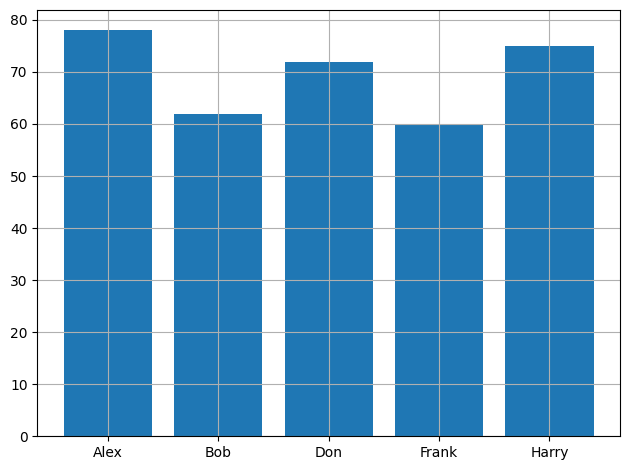

```python
names = ['Alex','Bob','Don','Frank','Harry']
xPosition = range(1,6)
heights = [78,62,72,60,75]

fig,ax = plt.subplots(1,1)
ax.bar(xPosition,heights,tick_label=names)

ax.grid()
fig.tight_layout()
plt.savefig("VisualizationPart07.zzz.png")
plt.show()
```

## **Description of the image shown above, VisualizationPart07.01.png**

### Type of Image

This figure is a simple vertical bar chart. Each bar represents the height of one member of a basketball team, with the bars arranged along the horizontal axis according to the players' names.

### Overall Summary

The image provides a visual comparison of the heights of five individuals. Each bar corresponds to a player, and the height of the bar indicates that player's height in inches. The chart makes it easy to compare the values and observe differences among the players.

### Purpose of the Image

The purpose of this image is to demonstrate how a bar chart can be used to display values associated with categorical data. In this case, the categories are player names, and the values are their heights. The chart illustrates how bar charts provide a clear visual comparison of numerical values across different categories.

## Cosmetic improvement

The following code adds some cosmetic improvements to the bar chart by adding labels to the axes and adding a title.

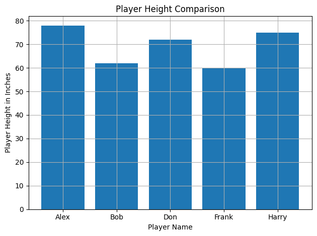

```python
names = ['Alex','Bob','Don','Frank','Harry']
xPosition = range(1,6)
heights = [78,62,72,60,75]

fig,ax = plt.subplots(1,1)
ax.bar(xPosition,heights,tick_label=names)
ax.set_xlabel('Player Name')
ax.set_ylabel('Player Height in Inches')
ax.set_title('Player Height Comparison')

ax.grid()
fig.tight_layout()
plt.savefig("VisualizationPart07.zzz.png")
plt.show()
```

## **Description of the image shown above, VisualizationPart07.02.png**

### Type of Image

This figure is a vertical bar chart with labeled axes and a descriptive title. Each bar represents the height of one member of a basketball team, and the bars are arranged along the horizontal axis according to the players' names.

### Overall Summary

The image provides a visual comparison of the heights of five individuals. The addition of axis labels and a title enhances clarity by identifying the meaning of the horizontal and vertical axes and summarizing the purpose of the chart. The chart makes it easy to compare the values and observe differences among the players.

### Purpose of the Image

The purpose of this image is to demonstrate how cosmetic improvements such as axis labels and a title can enhance the readability and interpretability of a bar chart. These additions help viewers understand what the bars represent and provide context for comparing the numerical values across categories.

## A horizontal bar chart

The following code displays a horizontal bar chart for the same data.

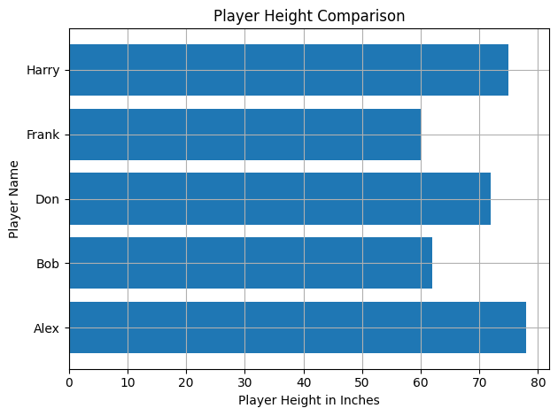

```python
names = ['Alex','Bob','Don','Frank','Harry']
xPosition = range(1,6)
heights = [78,62,72,60,75]

fig,ax = plt.subplots(1,1)
ax.barh(xPosition,heights,tick_label=names)

ax.set_ylabel('Player Name')
ax.set_xlabel('Player Height in Inches')
ax.set_title('Player Height Comparison')
ax.grid()
fig.tight_layout()
plt.savefig("VisualizationPart07.zzz.png")
plt.show()
```

## **Description of the image shown above, VisualizationPart07.03.png**

### Type of Image

This figure is a horizontal bar chart. Each bar represents the height of one member of a basketball team, with the bars arranged vertically according to the players' names.

### Overall Summary

The image provides a visual comparison of the heights of five individuals. The horizontal orientation of the bars makes it easy to read the height values along the horizontal axis while keeping the player names clearly visible along the vertical axis.

### Purpose of the Image

The purpose of this image is to demonstrate how a horizontal bar chart can be used to display values associated with categorical data. In this case, the categories are player names, and the values are their heights. The chart illustrates how horizontal bars can provide a clear visual comparison of numerical values across different categories.

## Bar chart with multiple x-values

Suppose we want to compare the individual scores achieved by each of our five basketball players in three consecutive games. We can accomplish that with the following code, which shows the three scores for each player in a side-by-side bar chart display. This chart also includes a legend that links the colors to the game number.

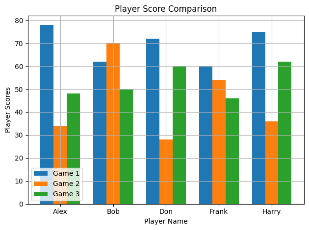

```python
names = ['Alex','Bob','Don','Frank','Harry']

xPosition = np.arange(5)
game01 = [78,62,72,60,75]
game02 = [34,70,28,54,36]
game03 = [48,50,60,46,62]

width = 0.25

fig,ax = plt.subplots(1,1)
ax.bar(xPosition,game01,width,label="Game 1")
ax.bar(xPosition+width,game02,width,label="Game 2",tick_label=names)
ax.bar(xPosition+width*2,game03,width,label="Game 3")
ax.set_xlabel('Player Name')
ax.set_ylabel('Player Scores')
ax.set_title('Player Score Comparison')

ax.grid()
plt.legend(loc='lower left')
fig.tight_layout()
plt.savefig("VisualizationPart07.zzz.png")
plt.show()
```

## **Description of the image shown above, VisualizationPart07.04.png**

### Type of Image

This figure is a grouped vertical bar chart. For each player, three bars appear side by side to show the scores achieved in three different games. The bars are color‑coded, and a legend identifies the game associated with each color.

### Overall Summary

The image provides a comparison of individual player performance across three consecutive games. Each group of bars corresponds to one player, and the height of each bar represents that player's score in a specific game. The chart makes it easy to observe differences in performance both within and across players.

### Purpose of the Image

The purpose of this image is to demonstrate how a grouped bar chart can be used to compare multiple values within each category. In this case, the categories are player names, and the values are the scores achieved in three different games. The chart illustrates how side‑by‑side bars allow viewers to compare performance across games for each player and to identify patterns or differences among players.

## A stacked bar chart

Another way to compare the individual scores achieved by each of our five players in three consecutive games is to stack the scores. We can accomplish that with the following code.

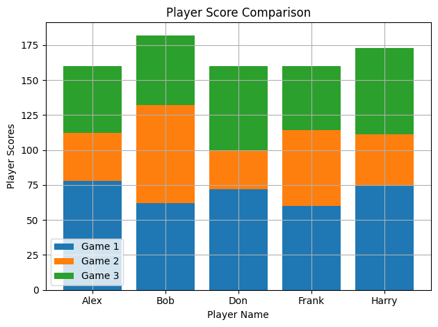

```python
names = ['Alex','Bob','Don','Frank','Harry']

xPosition = np.arange(5)
game01 = np.array([78,62,72,60,75])
game02 = np.array([34,70,28,54,36])
game03 = np.array([48,50,60,46,62])

fig,ax = plt.subplots(1,1)
ax.bar(xPosition,game01,bottom=0,label="Game 1",tick_label=names)
ax.bar(xPosition,game02,bottom=game01,label="Game 2")
ax.bar(xPosition,game03,bottom=(game01+game02),label="Game 3")
ax.set_xlabel('Player Name')
ax.set_ylabel('Player Scores')
ax.set_title('Player Score Comparison')

ax.grid()
plt.legend(loc='lower left')
fig.tight_layout()
plt.savefig("VisualizationPart07.zzz.png")
plt.show()
```

## **Description of the image shown above, VisualizationPart07.05.png**

### Type of Image

This figure is a stacked vertical bar chart. For each player, three colored segments are stacked on top of one another to show the scores achieved in three different games. A legend identifies the game associated with each color.

### Overall Summary

The image provides a comparison of total and component scores for five players across three consecutive games. Each bar represents one player, and the stacked segments show how much each game contributes to the player's overall score. The chart makes it easy to compare both individual game performance and total performance among the players.

### Detailed Description

The horizontal axis is labeled “Player Name” and displays five names: Alex, Bob, Don, Frank, and Harry. Above each name is a single vertical bar composed of three stacked segments. The vertical axis is labeled “Player Scores” and shows numerical values increasing from 0 to 175 in increments of 25. The bottom segment of each bar represents Game 1, the middle segment represents Game 2, and the top segment represents Game 3. Bob’s bar is the tallest, indicating the highest total score. The other players have similar total heights, with variations in how the individual game scores contribute to the total. A legend in the lower left corner identifies the colors associated with Game 1, Game 2, and Game 3. A grid is visible behind the bars, making it easier to estimate the height of each segment. The title “Player Score Comparison” appears above the chart.

### Purpose of the Image

The purpose of this image is to demonstrate how a stacked bar chart can be used to compare multiple values within each category while also showing the total value. In this case, the categories are player names, and the values are the scores achieved in three different games. The chart illustrates how stacked bars allow viewers to compare both individual game contributions and overall performance among players.

## A basic pie chart

[Wikipedia](https://en.wikipedia.org/wiki/Pie_chart) describes a pie chart as follows:

*"A Pie chart (or a circle chart) is a circular statistical graphic which is divided into slices to illustrate numerical proportion. In a pie chart, the arc length of each slice (and consequently its central angle and area), is proportional to the quantity it represents. While it is named for its resemblance to a pie which has been sliced, there are variations on the way it can be presented. The earliest known pie chart is generally credited to William Playfair's Statistical Breviary of 1801.*

*Pie charts are very widely used in the business world and the mass media. However, they have been criticized and many experts recommend avoiding them, pointing out that research has shown it is difficult to compare different sections of a given pie chart, or to compare data across different pie charts. Pie charts can be replaced in most cases by other plots such as the bar chart, box plot or dot plots."*

If you examine the [pie chart documentation](https://matplotlib.org/2.0.2/api/_as_gen/matplotlib.axes.Axes.pie.html#matplotlib.axes.Axes.pie) you will see that the **Axes.pie** method takes many parameters that can be used to customize the appearance of the chart.

Continuing with our basketball theme, we will create a pie chart that can be used to visually compare the number of points scored by the player named Alex in seven consecutive games.

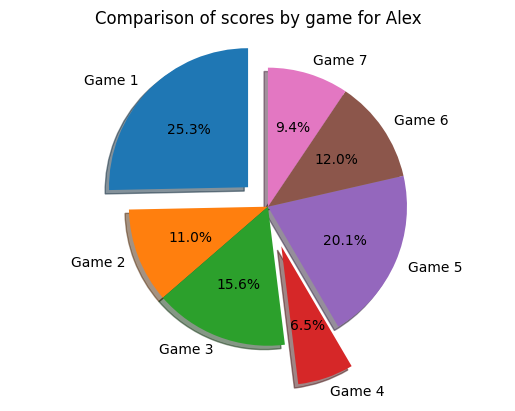

```python
games = 'Game 1', 'Game 2', 'Game 3', 'Game 4', 'Game 5','Game 6','Game 7'
points = [78, 34, 48, 20, 62, 37, 29]# points scored during each game
explodeSlices = (0.2, 0, 0, 0.3, 0, 0, 0)#explode largest and smallest
percentages = '%1.1f%%' #show percentage of each slice

fig1, ax = plt.subplots()
ax.pie(points, explode=explodeSlices, labels=games, autopct=percentages,
        shadow=True, startangle=90)
ax.axis('equal')  # ensure that pie is drawn as a circle.
ax.set_title('Comparison of scores by game for Alex')
fig.tight_layout()
plt.savefig("VisualizationPart07.zzz.png")
plt.show()
```

## **Description of the image shown above, VisualizationPart07.06.png**

### Type of Image

This figure is a pie chart. The circle is divided into seven slices, with each slice representing the number of points scored by a single player in one of seven consecutive games. Labels and percentage values appear next to each slice.

### Overall Summary

The image provides a visual comparison of the proportion of total points scored by the player Alex across seven games. Each slice of the pie corresponds to one game, and the size of the slice reflects the percentage of total points contributed by that game. The chart highlights which games contributed the most and least to the overall total.

### Detailed Description

The pie chart is titled “Comparison of scores by game for Alex.” It contains seven labeled slices arranged around the circle. Each slice displays a percentage value indicating the proportion of total points scored in that game. One of the larger slices corresponds to Game 1, while one of the smaller slices corresponds to Game 4. Some slices are offset slightly from the center to emphasize the largest and smallest values. The chart includes a shadow effect, and the start angle is rotated so that the first slice begins at the top of the circle. The axis is set to equal proportions so that the chart appears as a circle rather than an ellipse.

### Purpose of the Image

The purpose of this image is to demonstrate how a pie chart can be used to illustrate numerical proportions. In this case, the chart shows how the player Alex’s total points are distributed across seven games. The figure illustrates how pie charts can highlight relative contributions and make it easy to identify the largest and smallest portions of a dataset.

## Summary

This is the final exercise page on visualizations. However, we have barely scatched the surface in terms of what can be done with visualizations using matplotlib. It is strongly recommended that you visit the [matplotlib gallery](https://matplotlib.org/2.0.2/gallery.html) and work through the code for most, if not all of the examples provided there.

## Housekeeping material

Author: Prof. Richard G. Baldwin, Austin Community College, Austin, TX

File: VisualizationPart07.ipynb

Revised: 03/15/26

Copyright 2018 Richard G. Baldwin

-end-